# Shoot Apical Meristem (SAM) Morphology Analysis

Fausto Rodriguez

January 23, 2026

# Overview

This notebook analyzes shoot apical meristem (SAM) morphology in Inv4m and control (B73) plants. SAMs were cleared and imaged using differential interference contrast (DIC) microscopy from two-week-old seedlings grown in controlled environment chambers.

**Measurements:**

- **Height (h)**: Distance from the base to the apex of the SAM (μm)
- **Width**: Maximum diameter of the SAM (μm)
- **Radius (r)**: Half of the width (μm)

**Derived metrics (paraboloid model):**

- **h/r ratio**: Height-to-radius ratio (dimensionless)
- **Shape factor (h/r²)**: Indicates elongation; higher values = more elongated (nm⁻¹)
- **Arc length, surface area, volume**: Geometric properties assuming paraboloid shape

**Key hypothesis:** Inv4m plants have elongated SAMs compared to B73 controls, consistent with their accelerated flowering and increased plant height phenotypes.

# Load Libraries

```r
library(dplyr)
library(tidyr)
library(purrr)
library(ggplot2)
library(ggfx)
library(ggtext)
library(ggpubr)
library(ggbeeswarm)
library(rstatix)
library(broom)
library(knitr)
```

# Load and Process Data

```r
# Data file: SAM measurements from DIC microscopy
# Height and Width measured in micrometers (μm)
data_file <- file.path(paths$data, "MeristemMesurements_B73-INV_December2024.csv")

# Check if file exists
if (!file.exists(data_file)) {
  stop("Data file not found: ", data_file,
       "\nPlease copy MeristemMesurements_B73-INV_December2024.csv to the data directory.")
}

microscopy_raw <- read.csv(data_file) %>%
  dplyr::select(-starts_with("X"))  # Remove any empty columns

cat("Raw data dimensions:", dim(microscopy_raw), "\n")
```

```
## Raw data dimensions: 38 6
```

```r
cat("Columns:", paste(colnames(microscopy_raw), collapse = ", "), "\n")
```

```
## Columns: Plant., ID, Genotype, Width, Height, SurfaceArea
```

```r
# Calculate derived metrics using paraboloid approximation of SAM shape
microscopy <- microscopy_raw %>%
  mutate(
    # Basic derived measurements
    radius = Width / 2,
    hr_ratio = Height / radius,
    shape_factor = 1000 * Height / (radius^2),  # Units: nm⁻¹ (1000 factor converts μm to nm)

    # Paraboloid model calculations
    arc_length = sqrt(radius^2 + 4 * Height^2 +
                      (radius^2 / (2 * Height)) + asinh(2 * Height / radius)),
    area_section = (4/3) * (Height * radius),
    area_surface = pi * radius * ((radius^2 + 4 * Height^2)^(3/2) - radius^3) / (6 * Height^2),
    volume = pi * (Height * radius^2) / 2
  ) %>%
  # Standardize genotype labels
  mutate(
    Genotype = case_when(
      grepl("B73", Genotype, ignore.case = TRUE) ~ "CTRL",
      grepl("INV", Genotype, ignore.case = TRUE) ~ "Inv4m",
      TRUE ~ Genotype
    ),
    Genotype = factor(Genotype, levels = c("CTRL", "Inv4m"))
  )

cat("\nProcessed data dimensions:", dim(microscopy), "\n")
```

```
##
## Processed data dimensions: 38 13
```

```r
cat("Genotype counts:\n")
```

```
## Genotype counts:
```

```r
print(table(microscopy$Genotype))
```

```
##
##  CTRL Inv4m
##    18    20
```

# Summary Statistics

```r
# Define columns for analysis
primary_metrics <- c("Height", "radius", "hr_ratio", "shape_factor")

# Calculate summary statistics by genotype
summary_stats <- microscopy %>%
  group_by(Genotype) %>%
  summarise(
    n = n(),
    across(
      all_of(primary_metrics),
      list(
        mean = ~ mean(.x, na.rm = TRUE),
        sd = ~ sd(.x, na.rm = TRUE),
        sem = ~ sd(.x, na.rm = TRUE) / sqrt(sum(!is.na(.x))),
        median = ~ median(.x, na.rm = TRUE)
      ),
      .names = "{.col}_{.fn}"
    ),
    .groups = "drop"
  )

# Display summary
summary_stats %>%
  select(Genotype, n, starts_with("Height"), starts_with("radius")) %>%
  kable(digits = 2, caption = "SAM Height and Radius Summary Statistics")
```

SAM Height and Radius Summary Statistics

| Genotype | n | Height_mean | Height_sd | Height_sem | Height_median | radius_mean | radius_sd | radius_sem | radius_median |
| --- | --- | --- | --- | --- | --- | --- | --- | --- | --- |
| CTRL | 18 | 111.23 | 17.71 | 4.18 | 112.64 | 62.74 | 4.52 | 1.06 | 63.61 |
| Inv4m | 20 | 120.88 | 16.17 | 3.62 | 121.66 | 62.77 | 2.07 | 0.46 | 62.64 |

```r
summary_stats %>%
  select(Genotype, n, starts_with("hr_ratio"), starts_with("shape_factor")) %>%
  kable(digits = 3, caption = "SAM Shape Metrics Summary Statistics")
```

SAM Shape Metrics Summary Statistics

| Genotype | n | hr_ratio_mean | hr_ratio_sd | hr_ratio_sem | hr_ratio_median | shape_factor_mean | shape_factor_sd | shape_factor_sem | shape_factor_median |
| --- | --- | --- | --- | --- | --- | --- | --- | --- | --- |
| CTRL | 18 | 1.767 | 0.209 | 0.049 | 1.757 | 28.212 | 3.043 | 0.717 | 28.078 |
| Inv4m | 20 | 1.926 | 0.241 | 0.054 | 1.956 | 30.706 | 3.881 | 0.868 | 31.045 |

# Statistical Analysis: Linear Model Effects

We fit a linear model for each SAM metric to estimate the effect of Inv4m genotype compared to CTRL. This provides effect sizes with standard errors and p-values comparable to a two-sample t-test.

```r
# Fit linear models and extract Inv4m effects
lm_results <- map_df(primary_metrics, function(trait) {
  formula <- as.formula(paste(trait, "~ Genotype"))
  model <- lm(formula, data = microscopy)

  tidy(model) %>%
    filter(term == "GenotypeInv4m") %>%
    mutate(
      trait = trait,
      # Calculate 95% CI
      ci_lower = estimate - qt(0.975, model$df.residual) * std.error,
      ci_upper = estimate + qt(0.975, model$df.residual) * std.error,
      # Cohen's d effect size
      cohens_d = estimate / sd(microscopy[[trait]], na.rm = TRUE)
    ) %>%
    select(trait, estimate, std.error, statistic, p.value, ci_lower, ci_upper, cohens_d)
})

# Add units and format for display
lm_results_formatted <- lm_results %>%
  mutate(
    units = case_when(
      trait == "Height" ~ "μm",
      trait == "radius" ~ "μm",
      trait == "hr_ratio" ~ "",
      trait == "shape_factor" ~ "nm⁻¹"
    ),
    effect_str = case_when(
      trait %in% c("Height", "radius") ~ sprintf("%.2f ± %.2f %s", estimate, std.error, units),
      trait == "hr_ratio" ~ sprintf("%.3f ± %.3f", estimate, std.error),
      trait == "shape_factor" ~ sprintf("%.2f ± %.2f %s", estimate, std.error, units)
    ),
    p_str = ifelse(p.value < 0.001, sprintf("%.2e", p.value), sprintf("%.4f", p.value)),
    significance = case_when(
      p.value < 0.0001 ~ "****",
      p.value < 0.001 ~ "***",
      p.value < 0.01 ~ "**",
      p.value < 0.05 ~ "*",
      TRUE ~ "ns"
    )
  )

cat("\n=== Inv4m Effect on SAM Morphology (lm coefficients) ===\n\n")
```

```
##
## === Inv4m Effect on SAM Morphology (lm coefficients) ===
```

```r
lm_results_formatted %>%
  select(trait, effect_str, p_str, significance, cohens_d) %>%
  kable(
    col.names = c("Trait", "Effect (Inv4m - CTRL)", "p-value", "Sig.", "Cohen's d"),
    digits = 3,
    caption = "Effect of Inv4m genotype on SAM morphology metrics"
  )
```

Effect of Inv4m genotype on SAM morphology metrics

| Trait | Effect (Inv4m - CTRL) | p-value | Sig. | Cohen’s d |
| --- | --- | --- | --- | --- |
| Height | 9.65 ± 5.50 μm | 0.0876 | ns | 0.555 |
| radius | 0.03 ± 1.12 μm | 0.9779 | ns | 0.009 |
| hr_ratio | 0.158 ± 0.074 | 0.0382 | * | 0.667 |
| shape_factor | 2.49 ± 1.14 nm⁻¹ | 0.0354 | * | 0.677 |

# Statistical Analysis: One-Tailed t-Tests

Given our directional hypothesis that Inv4m plants have *larger/more elongated* SAMs, we also perform one-tailed t-tests.

```r
# Prepare data for t-tests
to_plot <- microscopy %>%
  pivot_longer(
    cols = all_of(primary_metrics),
    names_to = "trait",
    values_to = "value"
  ) %>%
  mutate(
    trait = factor(trait, levels = primary_metrics),
    Genotype_label = case_when(
      Genotype == "Inv4m" ~ "<i>Inv4m</i>",
      Genotype == "CTRL" ~ "CTRL"
    ),
    Genotype_label = factor(Genotype_label, levels = c("CTRL", "<i>Inv4m</i>"))
  )

# One-tailed t-tests (Inv4m > CTRL)
t_test_results <- to_plot %>%
  group_by(trait) %>%
  t_test(
    value ~ Genotype_label,
    ref.group = "CTRL",
    alternative = "less",  # Tests if CTRL < Inv4m
    detailed = TRUE
  ) %>%
  add_significance("p") %>%
  add_y_position(scales = "free_y")

# Adjust y positions for plotting
t_test_results$y.position <- 1.05 * t_test_results$y.position

cat("\n=== One-Tailed t-Tests (H₀: μ_Inv4m ≤ μ_CTRL) ===\n\n")
```

```
##
## === One-Tailed t-Tests (H₀: μ_Inv4m ≤ μ_CTRL) ===
```

```r
t_test_results %>%
  select(trait, estimate1, estimate2, statistic, p, p.signif) %>%
  mutate(
    diff = estimate2 - estimate1,
    pct_change = 100 * diff / estimate1
  ) %>%
  kable(
    col.names = c("Trait", "Mean CTRL", "Mean Inv4m", "t", "p", "Sig.", "Diff", "% Change"),
    digits = 3,
    caption = "One-tailed t-tests comparing SAM metrics between genotypes"
  )
```

One-tailed t-tests comparing SAM metrics between genotypes

| Trait | Mean CTRL | Mean Inv4m | t | p | Sig. | Diff | % Change |
| --- | --- | --- | --- | --- | --- | --- | --- |
| Height | 111.229 | 120.881 | -1.748 | 0.045 | * | 9.652 | 8.678 |
| radius | 62.739 | 62.770 | -0.027 | 0.489 | ns | 0.031 | 0.050 |
| hr_ratio | 1.767 | 1.926 | -2.169 | 0.018 | * | 0.158 | 8.966 |
| shape_factor | 28.212 | 30.706 | -2.215 | 0.017 | * | 2.494 | 8.838 |

# Visualization

## SAM Morphology Boxplots (Raw Values)

```r
# Color palette matching other figures
pal <- c(CTRL = "gold", `<i>Inv4m</i>` = "purple4")

# Theme matching ionome/phenotype plots
pheno_theme <- theme_classic2(base_size = 20) +
  theme(
    plot.title = element_markdown(hjust = 0.5, face = "bold"),
    axis.title.y = element_markdown(),
    axis.title.x = element_blank(),
    axis.text.x = element_markdown(color = "black", size = 20),
    strip.background = element_blank(),
    strip.text = element_markdown(size = 20),
    legend.position = "none"
  )

# Y-axis labels with units
yunit_labels <- c(
  Height = "Height<br><i>h</i> [μm]",
  radius = "Radius<br><i>r</i> [μm]",
  hr_ratio = "Ratio<br><i>h/r</i>",
  shape_factor = "Shape factor<br><i>h/r<sup>2</sup></i> [nm<sup>-1</sup>]"
)
```

```r
# Function to create individual trait plots
plot_sam_trait <- function(trait_name, data, t_results) {
  data %>%
    filter(trait == trait_name) %>%
    ggplot(aes(x = Genotype_label, y = value, color = Genotype_label)) +
    ggtitle(gsub("_", " ", trait_name)) +
    ylab(yunit_labels[trait_name]) +
    geom_boxplot(width = 0.25, linewidth = 1, alpha = 0) %>%
    with_shadow(colour = "black", x_offset = 0, y_offset = 0, sigma = 1) +
    geom_quasirandom(size = 2) %>%
    with_shadow(colour = "black", x_offset = 0, y_offset = 0, sigma = 1) +
    stat_pvalue_manual(
      t_results %>% filter(trait == trait_name),
      label = "p.signif",
      size = 10,
      bracket.size = 0.8,
      hide.ns = TRUE
    ) +
    scale_color_manual(values = pal) +
    scale_y_continuous(expand = expansion(mult = c(0.05, 0.15))) +
    pheno_theme +
    theme(plot.margin = unit(c(1, 0.5, 1, 0.5), "lines"))
}
```

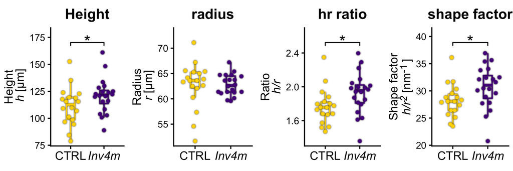

```r
# Create plots for primary metrics
sam_plots <- lapply(primary_metrics, plot_sam_trait, data = to_plot, t_results = t_test_results)

# Arrange in single row
sam_figure <- ggarrange(
  plotlist = sam_plots,
  nrow = 1,
  ncol = 4,
  align = "h"
)

print(sam_figure)
```

# Export Results

```r
# Export effect sizes for results text
effects_export <- lm_results_formatted %>%
  select(trait, estimate, std.error, p.value, ci_lower, ci_upper, cohens_d, units)

write.csv(
  effects_export,
  file.path(paths$intermediate, "SAM_morphology_effects.csv"),
  row.names = FALSE
)

# Export summary statistics
write.csv(
  summary_stats,
  file.path(paths$intermediate, "SAM_morphology_summary_stats.csv"),
  row.names = FALSE
)

# Save figure
ggsave(
  file.path(paths$figures, "SAM_morphology_boxplots.pdf"),
  sam_figure,
  width = 12,
  height = 4
)

ggsave(
  file.path(paths$figures, "SAM_morphology_boxplots.png"),
  sam_figure,
  width = 12,
  height = 4,
  dpi = 300
)

cat("\nExported files:\n")
```

```
##
## Exported files:
```

```r
cat("- ", file.path(paths$intermediate, "SAM_morphology_effects.csv"), "\n")
```

```
## -  /Users/fvrodriguez/Library/CloudStorage/GoogleDrive-frodrig4@ncsu.edu/My Drive/repos/inv4m/results/inversion_paper/intermediate/SAM_morphology_effects.csv
```

```r
cat("- ", file.path(paths$intermediate, "SAM_morphology_summary_stats.csv"), "\n")
```

```
## -  /Users/fvrodriguez/Library/CloudStorage/GoogleDrive-frodrig4@ncsu.edu/My Drive/repos/inv4m/results/inversion_paper/intermediate/SAM_morphology_summary_stats.csv
```

```r
cat("- ", file.path(paths$figures, "SAM_morphology_boxplots.pdf"), "\n")
```

```
## -  /Users/fvrodriguez/Library/CloudStorage/GoogleDrive-frodrig4@ncsu.edu/My Drive/repos/inv4m/results/inversion_paper/figures/SAM_morphology_boxplots.pdf
```

```r
cat("- ", file.path(paths$figures, "SAM_morphology_boxplots.png"), "\n")
```

```
## -  /Users/fvrodriguez/Library/CloudStorage/GoogleDrive-frodrig4@ncsu.edu/My Drive/repos/inv4m/results/inversion_paper/figures/SAM_morphology_boxplots.png
```

# Results Summary for Manuscript

```r
# Generate formatted text for results section
cat("\n=== Formatted Results for Manuscript ===\n\n")
```

```
##
## === Formatted Results for Manuscript ===
```

```r
for (i in 1:nrow(lm_results_formatted)) {
  row <- lm_results_formatted[i, ]
  trait_name <- switch(row$trait,
    "Height" = "SAM height",
    "radius" = "SAM radius",
    "hr_ratio" = "height-to-radius ratio (h/r)",
    "shape_factor" = "shape factor (h/r²)"
  )

  cat(sprintf(
    "%s: %.2f ± %.2f %s (p = %s)\n",
    trait_name,
    row$estimate,
    row$std.error,
    row$units,
    row$p_str
  ))
}
```

```
## SAM height: 9.65 ± 5.50 μm (p = 0.0876)
## SAM radius: 0.03 ± 1.12 μm (p = 0.9779)
## height-to-radius ratio (h/r): 0.16 ± 0.07  (p = 0.0382)
## shape factor (h/r²): 2.49 ± 1.14 nm⁻¹ (p = 0.0354)
```

```r
# Percent changes
cat("\n=== Percent Changes ===\n\n")
```

```
##
## === Percent Changes ===
```

```r
pct_changes <- t_test_results %>%
  mutate(
    pct_change = 100 * (estimate2 - estimate1) / estimate1
  ) %>%
  select(trait, pct_change)

for (i in 1:nrow(pct_changes)) {
  cat(sprintf("%s: %.1f%% increase\n", pct_changes$trait[i], pct_changes$pct_change[i]))
}
```

```
## Height: 8.7% increase
## radius: 0.0% increase
## hr_ratio: 9.0% increase
## shape_factor: 8.8% increase
```